# 001_analyzing_price_index_housing_cpi_related

- Using CPI/inflation as `NPV` or `today's dollars` housing comparison is most likely is not a good way
- **It is possible that** Singapore Residential Property Price Index **is one good approach**
- It is possible can use: SRX Property Index (SPI), or Singapore Real Estate Exchange (SRX)

```python
import requests
import iplotter
import pandas as pd
import matplotlib.pyplot as plt
import seaborn as sns
from IPython.display import display, HTML
from IPython.display import IFrame
display(HTML("<style>.container { width:100% !important; }</style>"))
```

**Raw Data Source** - - - > https://data.gov.sg/dataset/hdb-resale-price-index

**About this dataset:**

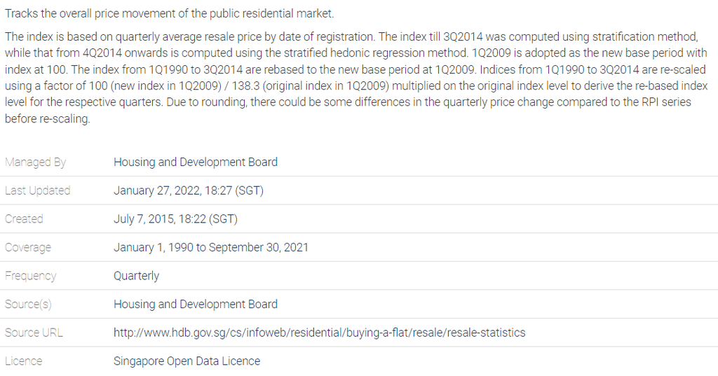

**Data Range:** January 1, 1990 to September 30, 2021

*Problem: We dont have anything beyond Sept 2021 to use as a CPI like indicator*

**The Plot:**

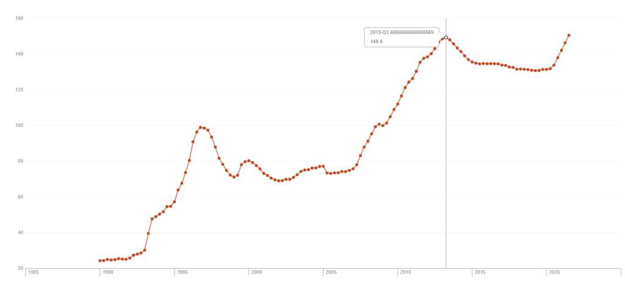

```python
#  %%html
#  <iframe width="600" height="400" src="https://data.gov.sg/dataset/hdb-property-information/resource/482bfa14-2977-4035-9c61-c85f871daf4e/view/82d8145d-daa6-460b-b269-9848c99ed32d" frameBorder="0"> </iframe>
#  IFrame('https://data.gov.sg/dataset/hdb-property-information/resource/482bfa14-2977-4035-9c61-c85f871daf4e/view/82d8145d-daa6-460b-b269-9848c99ed32d', width=700, height=350)
```

```python
# import urllib
# url = 'https://data.gov.sg/api/action/datastore_search?resource_id=482bfa14-2977-4035-9c61-c85f871daf4e&limit=5&q=title:jones'
# fileobj = urllib.urlopen(url)
# print fileobj.read()
```

[output not shown]

### Looking into D3 Viz

http://markibrahim.me/musings/notebooks/beautiful_javascript_charts.html

For simple, plots iPlotter brings the latest D3.js and canvas charting libraries to Jupyter Notebooks using native python data structures. iPlotter integrates with C3.js, plotly.js, Chart.js, Chartist.js, and Google Charts.

```python
# remove iFrame border for cleaner chart rendering
# increase size of text explanations
HTML("""
<style>
iframe {border:0;}
</style>
""")
```

```python
# define chart + data
chart = {
    "data": {
        "columns": [
            ["setosa_x", 3.5, 3.0, 3.2, 3.1, 3.6, 3.9, 3.4, 3.4, 2.9, 3.1, 3.7, 3.4, 3.0, 3.0, 4.0, 4.4, 3.9, 3.5, 3.8, 3.8, 3.4, 3.7, 3.6, 3.3, 3.4, 3.0, 3.4, 3.5, 3.4, 3.2, 3.1, 3.4, 4.1, 4.2, 3.1, 3.2, 3.5, 3.6, 3.0, 3.4, 3.5, 2.3, 3.2, 3.5, 3.8, 3.0, 3.8, 3.2, 3.7, 3.3],
            ["versicolor_x", 3.2, 3.2, 3.1, 2.3, 2.8, 2.8, 3.3, 2.4, 2.9, 2.7, 2.0, 3.0, 2.2, 2.9, 2.9, 3.1, 3.0, 2.7, 2.2, 2.5, 3.2, 2.8, 2.5, 2.8, 2.9, 3.0, 2.8, 3.0, 2.9, 2.6, 2.4, 2.4, 2.7, 2.7, 3.0, 3.4, 3.1, 2.3, 3.0, 2.5, 2.6, 3.0, 2.6, 2.3, 2.7, 3.0, 2.9, 2.9, 2.5, 2.8],
            ["setosa", 0.2, 0.2, 0.2, 0.2, 0.2, 0.4, 0.3, 0.2, 0.2, 0.1, 0.2, 0.2, 0.1, 0.1, 0.2, 0.4, 0.4, 0.3, 0.3, 0.3, 0.2, 0.4, 0.2, 0.5, 0.2, 0.2, 0.4, 0.2, 0.2, 0.2, 0.2, 0.4, 0.1, 0.2, 0.2, 0.2, 0.2, 0.1, 0.2, 0.2, 0.3, 0.3, 0.2, 0.6, 0.4, 0.3, 0.2, 0.2, 0.2, 0.2],
            ["versicolor", 1.4, 1.5, 1.5, 1.3, 1.5, 1.3, 1.6, 1.0, 1.3, 1.4, 1.0, 1.5, 1.0, 1.4, 1.3, 1.4, 1.5, 1.0, 1.5, 1.1, 1.8, 1.3, 1.5, 1.2, 1.3, 1.4, 1.4, 1.7, 1.5, 1.0, 1.1, 1.0, 1.2, 1.6, 1.5, 1.6, 1.5, 1.3, 1.3, 1.3, 1.2, 1.4, 1.2, 1.0, 1.3, 1.2, 1.3, 1.3, 1.1, 1.3]
        ],
     "type": 'scatter'
            },
    "axis": {
        "x": {
            "label": 'Sepal.Width',
            "tick": {
                "fit": "false"
            }
        },
        "y": {
            "label": 'Petal.Width'
        }
    }
}
```

```python
c3_plotter = iplotter.C3Plotter()
c3_plotter.plot(chart)
```

[interactive chart not shown]

```python
chart = {
    "data": {
        "columns": [
            ['dogs', 300, 350, 300, 0, 0, 120],
            ['cats', 130, 100, 140, 200, 150, 50],
            ['people', 180, 75, 265, 100, 50, 100]
        ],
        "types": {
            "dogs": 'area-spline',
            "cats": 'area-spline',
            "people": 'area-spline'
        },
        "groups": [['dogs', 'cats', 'people']]
    }
}
```

```python
c3_plotter = iplotter.C3Plotter()
c3_plotter.plot(chart)
```

[interactive chart not shown]

```python
labels = ["Red", "Blue", "Yellow", "Green", "Purple", "Orange"]
values = [{"x":20, "y": 30, "r":15}, {"x":40, "y":10, "r":10}]
```

```python
data = {
    "labels": labels,
    "datasets": [
        {
            "label": "My First dataset",
            "backgroundColor": "rgba(179,181,198,0.2)",
            "borderColor": "rgba(179,181,198,1)",
            "pointBackgroundColor": "rgba(179,181,198,1)",
            "pointBorderColor": "#fff",
            "pointHoverBackgroundColor": "#fff",
            "pointHoverBorderColor": "rgba(179,181,198,1)",
            "data": [65, 59, 90, 81, 56, 55, 40]
        },
        {
            "label": "My Second dataset",
            "backgroundColor": "rgba(255,99,132,0.2)",
            "borderColor": "rgba(255,99,132,1)",
            "pointBackgroundColor": "rgba(255,99,132,1)",
            "pointBorderColor": "#fff",
            "pointHoverBackgroundColor": "#fff",
            "pointHoverBorderColor": "rgba(255,99,132,1)",
            "data": [28, 48, 40, 19, 96, 27, 100]
        }
    ]
}
```

```python
chart_js = iplotter.ChartJSPlotter()
chart_js.plot(data, chart_type="radar", w=600, h=600)
```

[interactive chart not shown]

```python
# WE COULD USE THE ABOVE FOR D3 LIKE PLOTS ! ! ! !
# (LOOKS PRETTY GOOD)
```

```python
df = pd.read_csv(r'D:\GITHUB_Repos\Singapore\ENTER\data\hpi\housing-and-development-board-resale-price-index-1q2009-100-quarterly.csv')
```

```python
df
```

|  | quarter | index |
| --- | --- | --- |
| 0 | 1990-Q1 | 24.3 |
| 1 | 1990-Q2 | 24.4 |
| 2 | 1990-Q3 | 25.0 |
| 3 | 1990-Q4 | 24.7 |
| 4 | 1991-Q1 | 24.9 |
| ... | ... | ... |
| 122 | 2020-Q3 | 133.9 |
| 123 | 2020-Q4 | 138.1 |
| 124 | 2021-Q1 | 142.2 |
| 125 | 2021-Q2 | 146.4 |
| 126 | 2021-Q3 | 150.6 |

127 rows × 2 columns

```python
df['quarter'] = pd.to_datetime(df['quarter'])
df['quarter'] = df['quarter'].dt.to_period('Q')
# or could do this:
# df['quarter_custom'] = df['StartDate'].dt.to_period('Q').dt.strftime('q%q %y\'')
```

```python
df
```

|  | quarter | index |
| --- | --- | --- |
| 0 | 1990Q1 | 24.3 |
| 1 | 1990Q2 | 24.4 |
| 2 | 1990Q3 | 25.0 |
| 3 | 1990Q4 | 24.7 |
| 4 | 1991Q1 | 24.9 |
| ... | ... | ... |
| 122 | 2020Q3 | 133.9 |
| 123 | 2020Q4 | 138.1 |
| 124 | 2021Q1 | 142.2 |
| 125 | 2021Q2 | 146.4 |
| 126 | 2021Q3 | 150.6 |

127 rows × 2 columns

**Simple Plotting:**

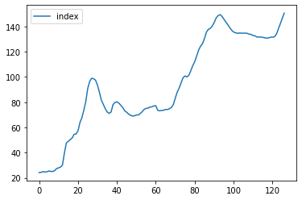

```python
df.plot();
# df.plot.line();
```

```python
# Make datetime values as index
df.set_index('quarter', inplace=True);
```

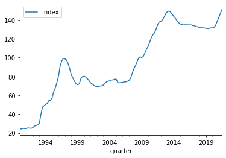

```python
df.plot();
```

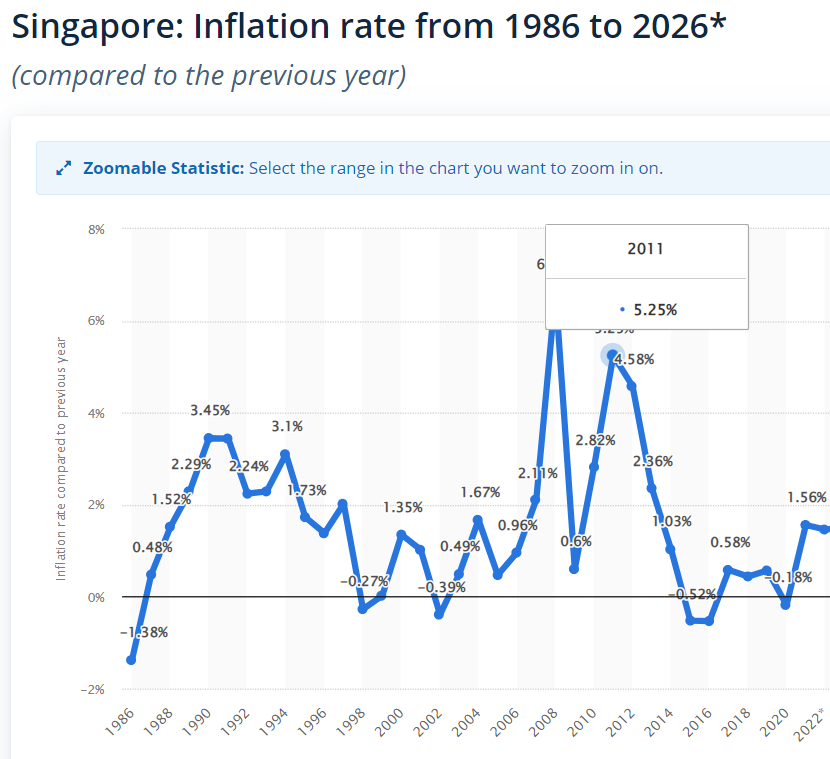

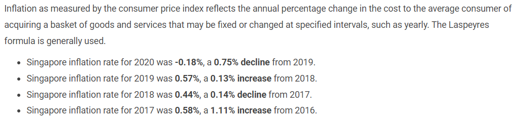

```python
# # sns.lineplot(x='size',y='total_bill',  hue = 'time', data=dataset, style ='time',
# #              palette = 'hot', dashes= False, markers= ["o","<"])

# sns.lineplot(x='quarter',y='index', data=df)
# # ,              palette = 'hot', dashes= False, markers= ["o","<"])
```

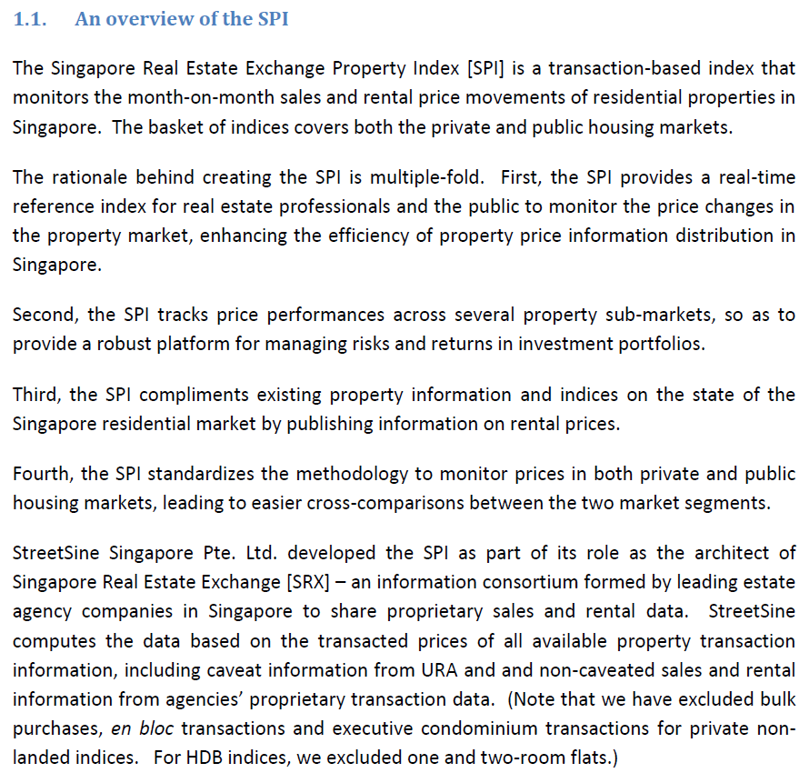

### Singapore Real Estate Exchange

```python
# potentially use this ?
```

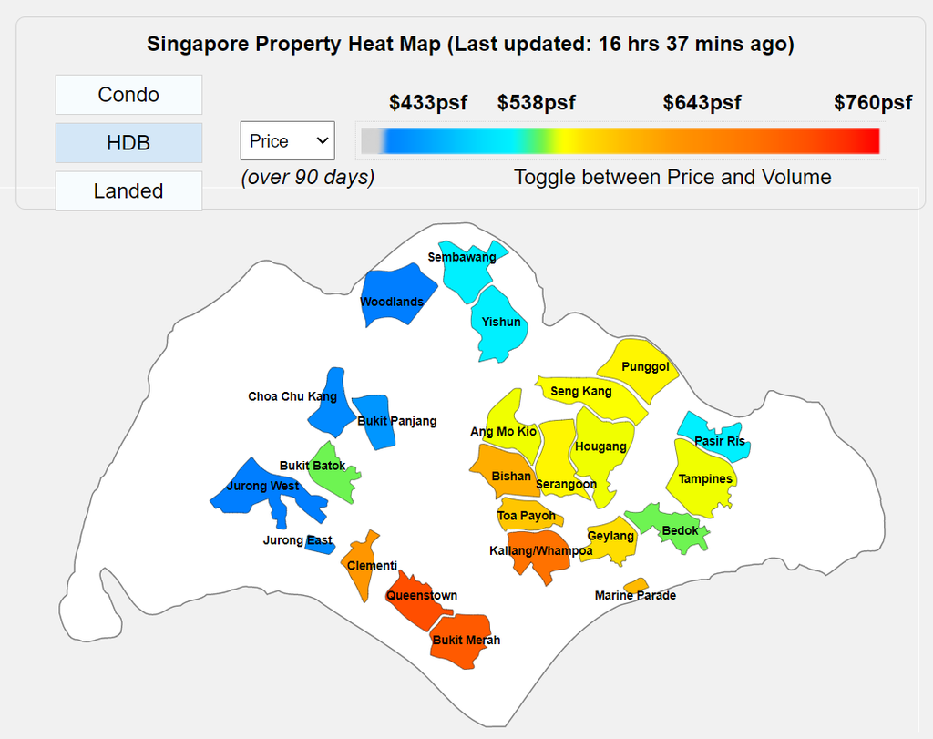

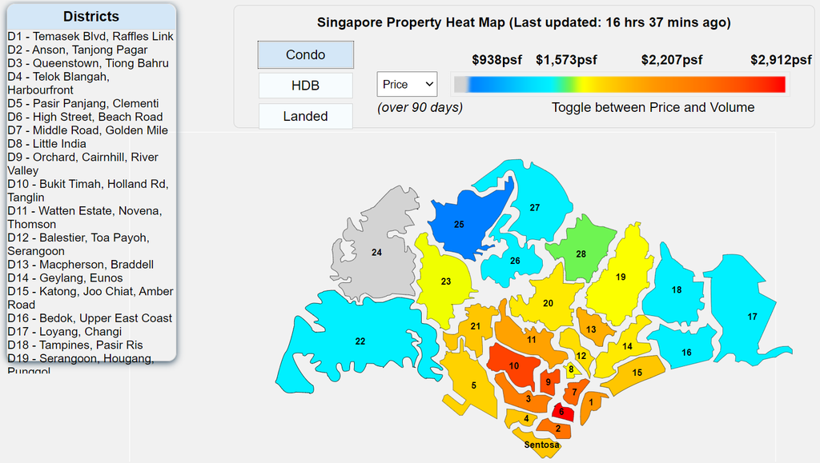

```
D1 - Temasek Blvd, Raffles Link
D2 - Anson, Tanjong Pagar
D3 - Queenstown, Tiong Bahru
D4 - Telok Blangah, Harbourfront
D5 - Pasir Panjang, Clementi
D6 - High Street, Beach Road
D7 - Middle Road, Golden Mile
D8 - Little India
D9 - Orchard, Cairnhill, River Valley
D10 - Bukit Timah, Holland Rd, Tanglin
D11 - Watten Estate, Novena, Thomson
D12 - Balestier, Toa Payoh, Serangoon
D13 - Macpherson, Braddell
D14 - Geylang, Eunos
D15 - Katong, Joo Chiat, Amber Road
D16 - Bedok, Upper East Coast
D17 - Loyang, Changi
D18 - Tampines, Pasir Ris
D19 - Serangoon, Hougang, Punggol
D20 - Bishan, Ang Mo Kio
D21 - Upper Bukit Timah, Ulu Pandan
D22 - Jurong
D23 - Bukit Panjang, Choa Chu Kang
D24 - Lim Chu Kang, Tengah
D25 - Kranji, Woodgrove
D26 - Upper Thomson, Springleaf
D27 - Yishun, Sembawang
D28 - Seletar
```

### Specifically Focusing on MRTs:

https://www.srx.com.sg/mrt-home-prices

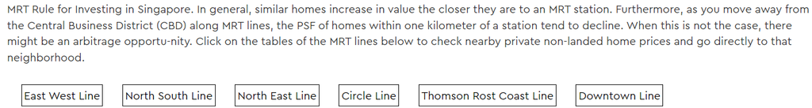

MRT Rule for Investing in Singapore. In general, similar homes increase in value the closer they are to an MRT station. Furthermore, as you move away from the Central Business District (CBD) along MRT lines, the PSF of homes within one kilometer of a station tend to decline. When this is not the case, there might be an arbitrage opportu-nity. Click on the tables of the MRT lines below to check nearby private non-landed home prices and go directly to that neighborhood.

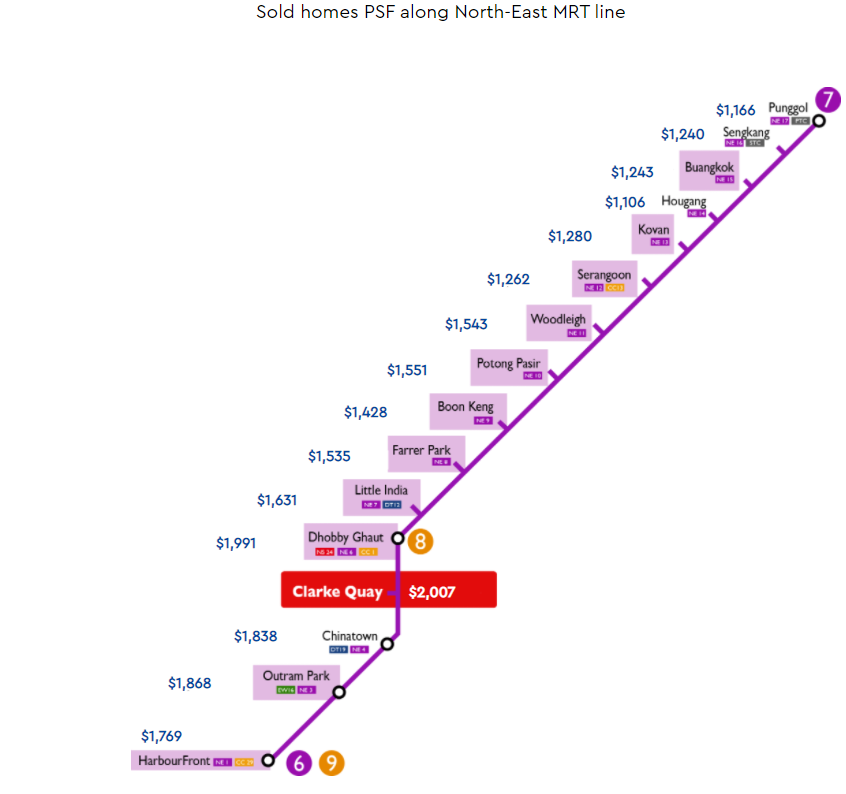

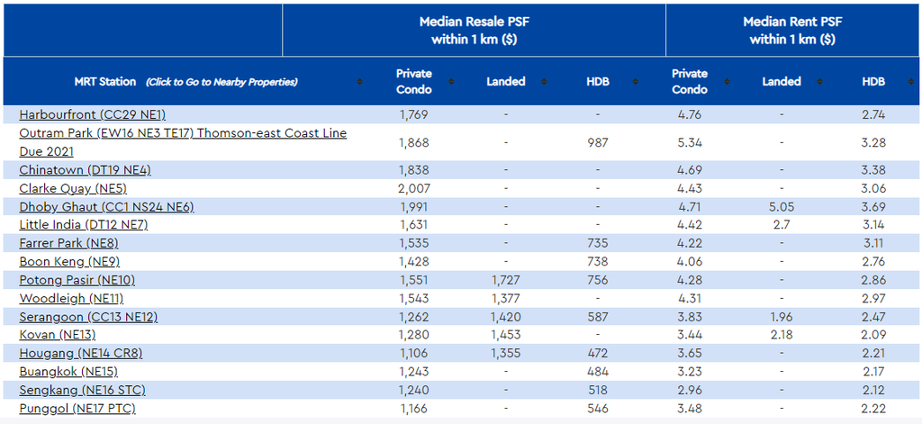

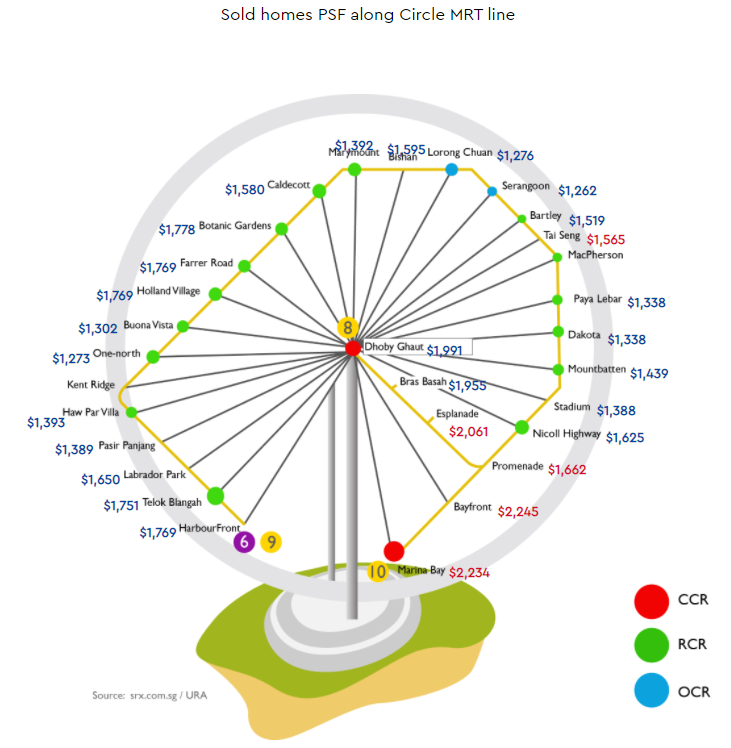

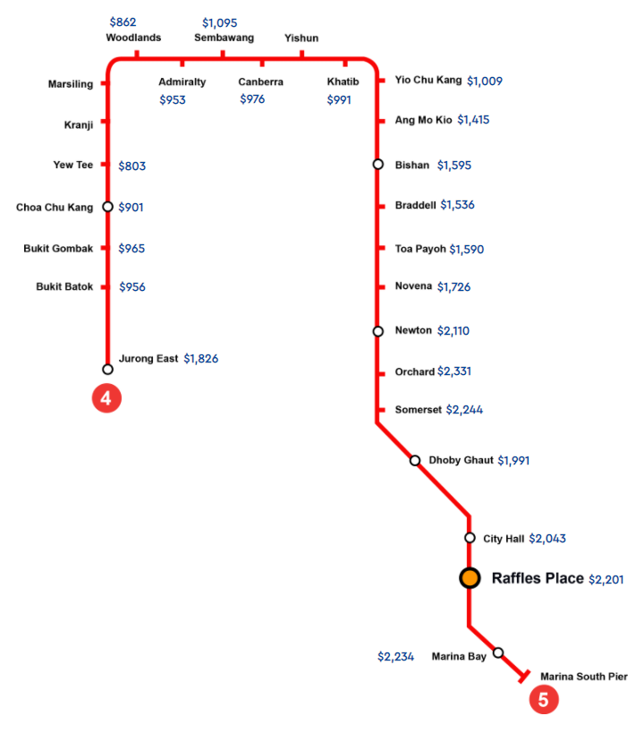

https://www.srx.com.sg/mrt-home-prices

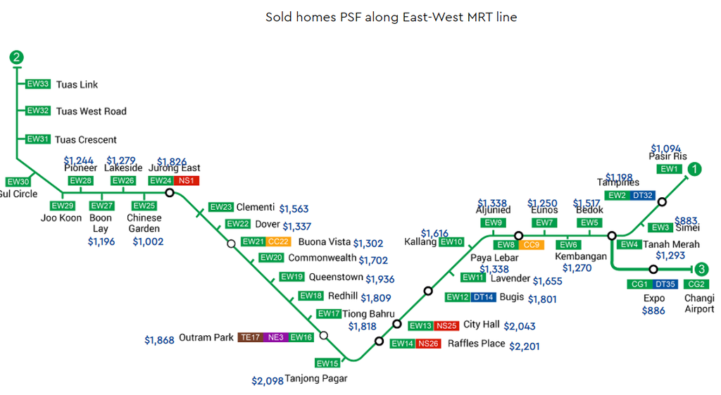

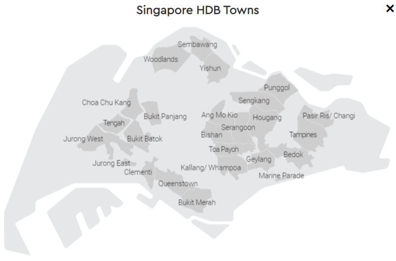